# TATA analysis (EPD)

Martin Iungman

2022-08-16

Este informe es un analisis exploratorio con la base de datos de EPD para evaluar la presencia de TATA box en los promotores. A su vez, se analiza si la proporción de promotores TATA, del total de promotores del gene, responde a una distribución al azar.

En primer lugar, armo promotores de 100 pares de abajo hacia rio arriba del TSS.  
Elijo este ancho de búsqueda por tres razones: para un TSS en la posición 0, espero que un TATA funcional esté en el -30, por lo que no tiene sentido usar un promotor grande. A su vez, dada la distancia entre promotores alternativos, si tomo una distancia mas grande, puedo empezar a superponer promotores y por lo tanto contar el mismo TATA dos veces. Sin embargo, dado que esta base de datos junta TSS que se encuentran muy proximos, por lo que hay un TSS en la posición en 0, pero también puede haber en otras posiciones. Reducir el area de busqueda haría que pierda los TATA referidos a estos otros TSS.

Uso un score minimo de 80% para la busqueda de TATA en esa region. Me quedo con aquellos que esten en la misma hebra que el TSS referido. Y cuando hay mas de uno, selecciono el de mayor score.

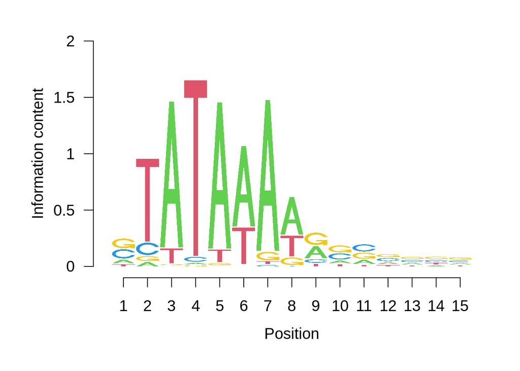

[output not shown]

```
## # A tibble: 7,492 × 2
##    gene  n_prom_tata
##    <chr>       <int>
##  1 A1CF            1
##  2 A2M             1
##  3 A2ML1           2
##  4 A4GNT           1
##  5 AADAC           1
##  6 AADAT           1
##  7 AANAT           1
##  8 AATF            1
##  9 AATK            1
## 10 ABAT            2
## # … with 7,482 more rows
## # ℹ Use `print(n = ...)` to see more rows
```

Ahora me fijo la posicion de los TATA. Deberian iniciar alrededor de la base -31

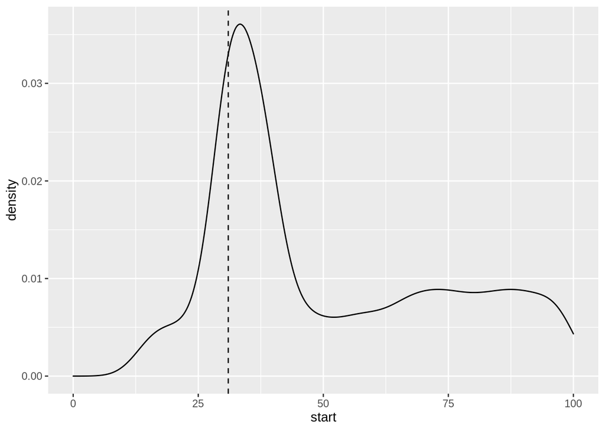

Da divino, estan bien posicionadas

Ahora me pregunto: Hay mayor proporcion de promotores TATA en promotores de genes con un unico promotor, o en promotores de genes con multiples promotores?  
Hago tabla de contingencia, y hago un test de Fisher

```
##
##         FALSE  TRUE
##   FALSE  5738  2695
##   TRUE  14143  7022
```

```
##
##  Fisher's Exact Test for Count Data
##
## data:  table(df_genes$mult_prom, df_genes$TATA)
## p-value = 0.04386
## alternative hypothesis: true odds ratio is not equal to 1
## 95 percent confidence interval:
##  1.001244 1.116224
## sample estimates:
## odds ratio
##   1.057124
```

Si bien da significativo… El Odds ratio es practicamente 1. No considero que haya relevancia biologica en esto  
Lo veo mejor en grafico:

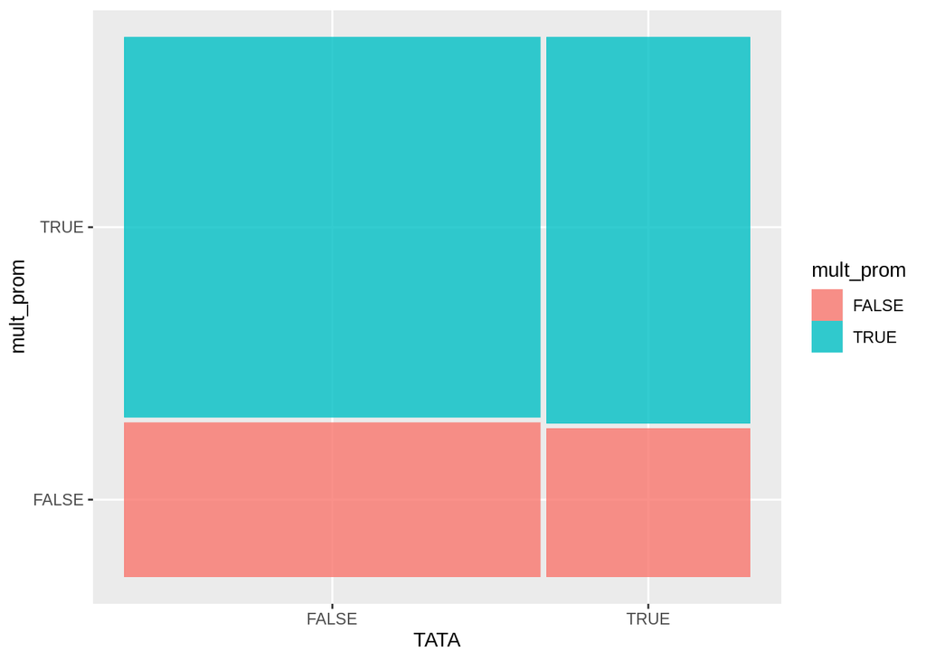

### Auotocorrelacion de TATAs

La pregunta es: es mas probable que, dado que hay una TATA en un promotor de un gen, haya otra TATA en el otro promotor?  
Lo pense como una situacion de desequilibrio de Hardy Weinberg, donde hay dos alelos posibles (con y sin TATA). Limitación: solo puedo para genes con dos promotores, dado que serían los dos “cromosomas”.

```
## Chi-square test with continuity correction for Hardy-Weinberg equilibrium (autosomal)
## Chi2 =  33.25879 DF =  1 p-value =  8.067416e-09 D =  -87.84923 f =  0.08222895
```

Da significativo.  
La D es 0.5*(Het_obs - Het_esp). Dado que dio negativo, indica que hay que hay menos “heterocigotas” de lo esperado. Sin embargo, los efectos no son muy grandes.

Sigue faltando un modelo con mas de dos promotores…

```
##   n_prom N_prom    N k        esp        obs obs_raw prop_TATA
## 1      1   8433 8433 0 0.31957785 0.31957785    2695       0.0
## 2      1   8433 8433 1 0.68042215 0.68042215    5738       1.0
## 3      2   9926 4963 0 0.09835800 0.11605884     576       0.0
## 4      2   9926 4963 1 0.43052558 0.39512392    1961       0.5
## 5      2   9926 4963 2 0.47111641 0.48881725    2426       1.0
## 6      3   5760 1920 0 0.03600511 0.04791667      92       0.0
```

```
## [[1]]
##
##  Chi-squared test for given probabilities
##
## data:  TATA_modelo %>% filter(n_prom == .x) %>% select(obs_raw) %>%     as_vector()
## X-squared = 33.558, df = 2, p-value = 5.164e-08
##
##
## [[2]]
##
##  Chi-squared test for given probabilities
##
## data:  TATA_modelo %>% filter(n_prom == .x) %>% select(obs_raw) %>%     as_vector()
## X-squared = 1384.4, df = 3, p-value < 2.2e-16
##
##
## [[3]]
##
##  Chi-squared test for given probabilities
##
## data:  TATA_modelo %>% filter(n_prom == .x) %>% select(obs_raw) %>%     as_vector()
## X-squared = 12.318, df = 4, p-value = 0.01514
##
##
## [[4]]
##
##  Chi-squared test for given probabilities
##
## data:  TATA_modelo %>% filter(n_prom == .x) %>% select(obs_raw) %>%     as_vector()
## X-squared = 2.177, df = 5, p-value = 0.8241
##
##
## [[5]]
##
##  Chi-squared test for given probabilities
##
## data:  TATA_modelo %>% filter(n_prom == .x) %>% select(obs_raw) %>%     as_vector()
## X-squared = 86.447, df = 6, p-value < 2.2e-16
```

| n_prom | N_prom | N | k | esp | obs | obs_raw | prop_TATA |
| --- | --- | --- | --- | --- | --- | --- | --- |
| 2 | 9926 | 4963 | 0 | 0.0983580 | 0.1160588 | 576 | 0.0000000 |
| 2 | 9926 | 4963 | 1 | 0.4305256 | 0.3951239 | 1961 | 0.5000000 |
| 2 | 9926 | 4963 | 2 | 0.4711164 | 0.4888172 | 2426 | 1.0000000 |
| 3 | 5760 | 1920 | 0 | 0.0360051 | 0.0479167 | 92 | 0.0000000 |
| 3 | 5760 | 1920 | 1 | 0.2190973 | 0.0000000 | 0 | 0.3333333 |
| 3 | 5760 | 1920 | 2 | 0.4444151 | 0.0000000 | 0 | 0.6666667 |
| 3 | 5760 | 1920 | 3 | 0.3004825 | 0.3140625 | 603 | 1.0000000 |